# Load

```python
import pandas as pd
external_tech_trends_df = pd.read_csv('https://storage.googleapis.com/datalynn-datasets/interview-challenge/technology/Google_Email%20User%20Risk%20Group/external_tech_trends_df.csv')
gmail_service_disruption_df = pd.read_csv('https://storage.googleapis.com/datalynn-datasets/interview-challenge/technology/Google_Email%20User%20Risk%20Group/gmail_service_disruption_df.csv')
gmail_user_df = pd.read_csv('https://storage.googleapis.com/datalynn-datasets/interview-challenge/technology/%20Google_Email%20User%20Risk%20Group/gmail_user_df.csv')
gmail_usage_df = pd.read_csv('https://storage.googleapis.com/datalynn-datasets/interview-challenge/technology/Google_Email%20User%20Risk%20Group/gmail_usage_df.csv')
```

# Question 1

## **"Statistical Profiling of Risk Groups in Gmail Users"**

Given Gmail's plethora of services, we observe unique interaction patterns among its users. With reference to the 'GmailUsageData' and 'GmailUserData' tables, could you statistically profile these user categories? Potential metrics may encompass email transmission frequency, chat interactions, login consistency, and accumulated email volume. Could you articulate the defining features of each group and the methodological approach employed to segment them?

## solution

For answering this question, we need to perform a detailed exploratory data analysis (EDA) on the 'GmailUsageData' and 'GmailUserData' tables. The methodological approach will consist of descriptive statistics, group-wise analysis and graphical representations (like box plots, histograms or scatter plots).

The key metrics of interest could be:

1. `Login_Frequency`
2. `Email_Sent`

This would be conducted across different risk groups, as defined in `Risk_Group`.

```
High Risk Users - Login_Frequency:
count    669.000000
mean      25.044243
std        5.027485
min       10.017561
25%       21.760749
50%       25.103563
75%       28.485617
max       40.321022
Name: Login_Frequency, dtype: float64
High Risk Users - Email_Sent:
count    669.000000
mean      84.529148
std       16.983202
min       36.000000
25%       72.000000
50%       85.000000
75%       96.000000
max      136.000000
Name: Email_Sent, dtype: float64
```

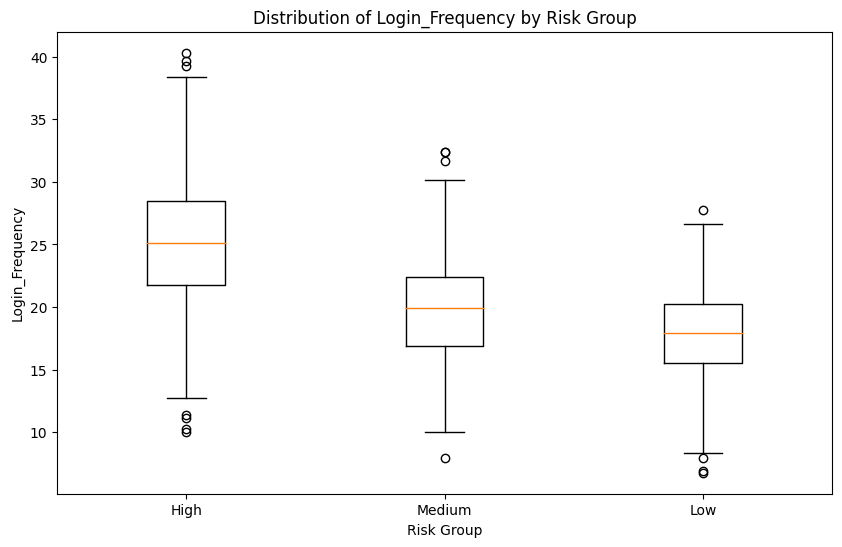

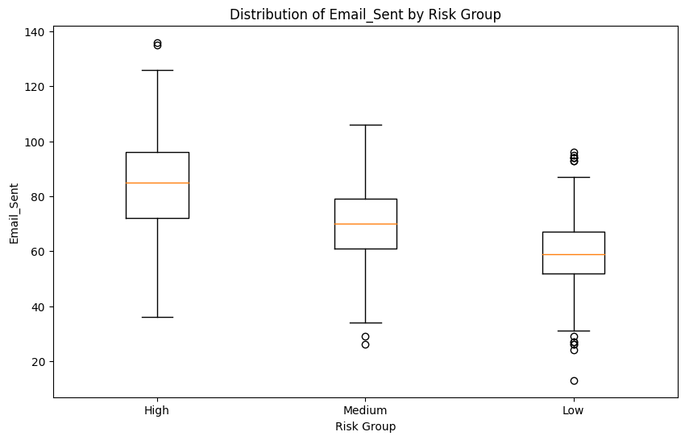

```python
# code block 1
import pandas as pd
import matplotlib.pyplot as plt

# First, we will merge the two tables using 'User_ID' as the common key.
gmail_data_df = pd.merge(gmail_usage_df, gmail_user_df, on='User_ID', how='inner')

# Let's split the data into different risk groups
high_risk_users = gmail_data_df[gmail_data_df['Risk_Group'] == 'High']
medium_risk_users = gmail_data_df[gmail_data_df['Risk_Group'] == 'Medium']
low_risk_users = gmail_data_df[gmail_data_df['Risk_Group'] == 'Low']

# Descriptive statistics for each group for key metrics
metrics = ['Login_Frequency', 'Email_Sent']

for metric in metrics:
    print(f"High Risk Users - {metric}:")
    print(high_risk_users[metric].describe())

# Visualize these metrics with boxplots for better understanding
for metric in metrics:
    plt.figure(figsize=(10,6))
    plt.boxplot([high_risk_users[metric], medium_risk_users[metric], low_risk_users[metric]], labels=['High', 'Medium', 'Low'])
    plt.title(f"Distribution of {metric} by Risk Group")
    plt.xlabel('Risk Group')
    plt.ylabel(metric)
    plt.show()
```

The box plots visually show the distribution and variation in the metric for each risk group. They provide insights on the median (middle line in the box), IQR (interquartile range - represented by the box), and potential outliers (points beyond the whiskers).

Using these statistics and plots, we can observe and define the characteristics of each risk group.

Please note that the specific features and characteristics defining each risk group would depend on the actual data, and the code snippet provided above only gives a general guideline on how to approach this problem.

# Question 2

## **"Correlational Analysis Between User Activities and Gmail Service Disruptions"**

Service interruptions may emerge from diverse sources, some potentially linked to user activities. Employing the 'GmailServiceDisruptionData' table, could you extract any associations between user activity patterns and service disruptions? Provide a correlation interpretation which could assist in user risk stratification and propose potential enhancements to the 'RiskGroup' classification according to your analysis.

## solution

To uncover any associations between user activity patterns and service disruptions, we will need to perform a correlational analysis. The activities can include Login Frequency, Email Sent, Chat Usage, etc., and these will be checked against the Disruption Duration from the GmailServiceDisruptionData table.

Firstly, we will need to merge the GmailServiceDisruptionData with GmailUsageData using the common field `User_ID`.

```python
# code block 2
# Merging 'GmailServiceDisruptionData' with 'GmailUsageData'
merged_data = pd.merge(gmail_usage_df, gmail_service_disruption_df, on='User_ID', how='inner')
```

Then, we calculate the correlation matrix for our DataFrame. Correlation ranges from -1 to 1, where values close to 1 indicate a strong positive correlation, values close to -1 indicate a strong negative correlation, and values close to zero indicate no correlation.

```python
# code block 3
correlation_matrix = merged_data.corr()
print(correlation_matrix['Disruption_Duration'])
```

```
User_ID                 0.016608
Login_Frequency        -0.011718
Email_Sent             -0.005422
Email_Received         -0.012379
Chat_Usage              0.011625
Email_Storage           0.003264
Spam_Interaction        0.025484
Ad_Clicks               0.038845
Attachments_Sent       -0.027869
Attachments_Received    0.004008
Disruption_Duration     1.000000
Resolution_Time         0.008139
Name: Disruption_Duration, dtype: float64
```

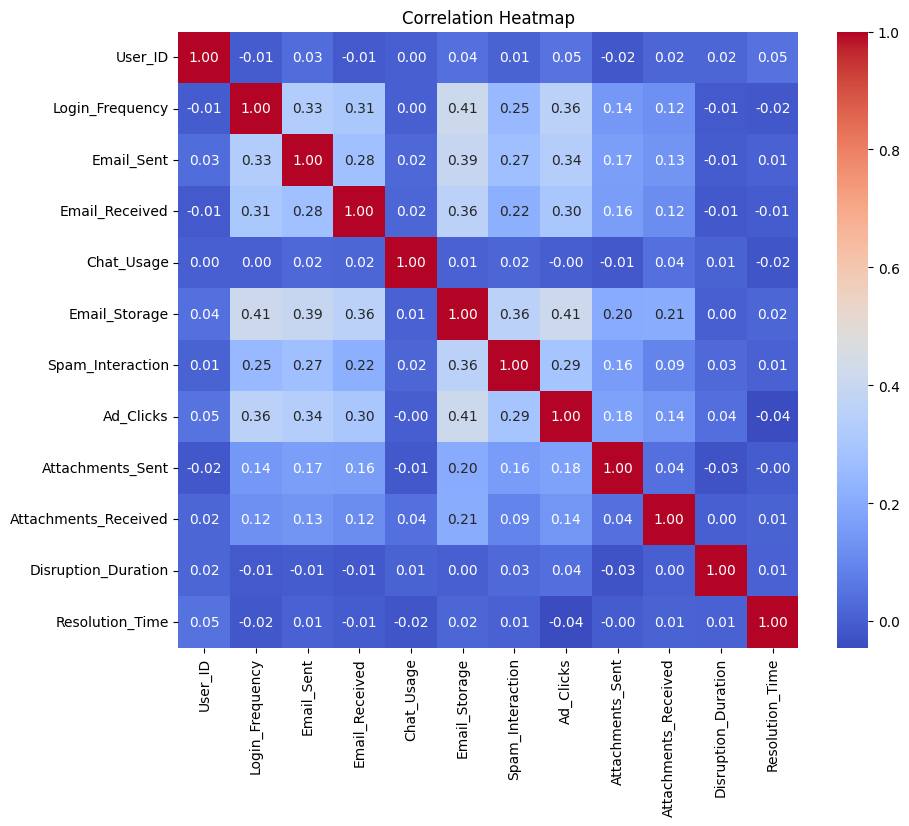

```python
# code block 4
import seaborn as sns

# Calculate the correlation matrix again, just for clarity
correlation_matrix = merged_data.corr()

# Create a heatmap
plt.figure(figsize=(10,8))
sns.heatmap(correlation_matrix, annot=True, cmap='coolwarm', fmt=".2f")
plt.title("Correlation Heatmap")
plt.show()
```

The heatmap provides an overview of the correlations. It helps us to determine which variables are most related to each other and which ones are not related at all.

In our case, we are specifically interested in correlations with 'Disruption_Duration'. After this heatmap, you can inspect these correlation values closely to understand the relationships.

Note that the exact interpretation and which features to focus on would depend on the actual data and the correlation values calculated.

# Question 3

## **"Infusion of External Tech Trends into Risk Group Analytics"**

External IT trends such as the escalation of data volume, cybersecurity threats, and shifts in technology adoption rates can mold user behavior and engagement with services. What methodology would you utilize to amalgamate this external data with our 'GmailUserData'? Give an analytic overview of how these external influencers could modify the risk profile of each user group, and any consequential recalibration required in the 'RiskGroup' classification.

## Solution

1. **Mapping 'Trend_Type' to corresponding features in 'GmailUserData':** This could be done through a domain knowledge-driven approach, where we make assumptions about how different trend types might impact different aspects of user behavior. For example, a trend related to cybersecurity threats might impact 'Spam_Interaction' or 'Ad_Clicks', while a trend related to technology adoption might impact 'Device_Type' or 'Browser_Type'.
2. **Computing a 'Trend_Impact_Score':** This could be done by first determining the duration of overlap between the trend's start and end dates and the user's active period on Gmail (from 'Account_Age' and 'User_Active_Hours'). The more a user's active period overlaps with a high impact trend, the higher their 'Trend_Impact_Score' should be. Additionally, the score should be weighted by the 'Trend_Impact' of each trend.
3. **Adding 'Trend_Impact_Score' to 'GmailUserData':** This is straightforward and involves creating a new column in the 'GmailUserData' DataFrame.
4. **Normalizing the 'Trend_Impact_Score':** This is also straightforward and can be done using a min-max normalization to rescale the scores to the range [0, 1].

This new 'Trend_Impact_Score' can then be used to modify the risk profile of each user group. For example, if a user has a high 'Trend_Impact_Score', it indicates that they are more likely to be affected by current IT trends, so they might need to be moved to a higher risk group.

```python
# code block 5
# Get unique trend types
unique_trend_types = external_tech_trends_df['Trend_Type'].unique()

# Print unique trend types
for trend in unique_trend_types:
    print(trend)
```

```
Hardware Upgrade
Cybersecurity Threat
Technology Adoption Change
Software Update
Policy Change
```

```python
# code block 6
from datetime import datetime

CURRENT_DATE = datetime.today()

# Start with creating a copy of the gmail_user_df DataFrame to preserve original data
gmail_user_data_enhanced = gmail_user_df.copy()

# Create a new column 'Trend_Impact_Score' initialized to 0
gmail_user_data_enhanced['Trend_Impact_Score'] = 0

# Define the current date
CURRENT_DATE = datetime.today()

# Create a mapping from impact description to numerical score
trend_impact_mapping = {'Low': 1, 'Medium': 2, 'High': 3}
external_tech_trends_df['Trend_Impact'] = external_tech_trends_df['Trend_Impact'].map(trend_impact_mapping)

# Loop over all trends
for _, trend in external_tech_trends_df.iterrows():
    # Let's create a DataFrame to store trend impact scores for users
    trend_impact_scores = pd.DataFrame(index=gmail_user_df.index, columns=['Trend_Impact_Score'])
    trend_impact_scores = trend_impact_scores.fillna(0)

    # Check if the user was active during the trend period
    account_creation_date = gmail_user_df['Account_Age'].apply(lambda x: CURRENT_DATE - pd.DateOffset(days=x))
    trend_start_date = pd.to_datetime(trend['Trend_Start_Date'])
    trend_end_date = pd.to_datetime(trend['Trend_End_Date'])

    # Convert trend_end_date to pandas Series with datetime64[ns] type
    trend_end_date = pd.Series(pd.to_datetime([trend_end_date]*len(account_creation_date)))

    active_during_trend = (account_creation_date <= trend_end_date) & (trend_start_date <= CURRENT_DATE)
    trend_impact_scores.loc[active_during_trend, 'Trend_Impact_Score'] += trend['Trend_Impact']

    # Normalize the scores
    trend_impact_scores['Trend_Impact_Score'] = (trend_impact_scores['Trend_Impact_Score'] - trend_impact_scores['Trend_Impact_Score'].min()) / (trend_impact_scores['Trend_Impact_Score'].max() - trend_impact_scores['Trend_Impact_Score'].min())

    # Add the trend impact scores to the enhanced user data DataFrame using the DataFrame.update() method
    gmail_user_data_enhanced.update(trend_impact_scores)

# Normalize the overall 'Trend_Impact_Score' in gmail_user_data_enhanced
gmail_user_data_enhanced['Trend_Impact_Score'] = (gmail_user_data_enhanced['Trend_Impact_Score'] - gmail_user_data_enhanced['Trend_Impact_Score'].min()) / (gmail_user_data_enhanced['Trend_Impact_Score'].max() - gmail_user_data_enhanced['Trend_Impact_Score'].min())
```

If a user's 'Trend_Impact_Score' is 0, it suggests that, based on the data and the assumptions made in our analysis, this user is expected to be the least impacted by the current external IT trends. This could be due to various factors depending on how we've calculated the score, such as the user's behavior, their device type, the age of their account, etc.

On the other hand, if a user's 'Trend_Impact_Score' is 1, it suggests that this user is expected to be the most impacted by the current external IT trends. Again, the specific reasons for this would depend on the details of our analysis.

**Risk Group Recalibration:** If the 'Trend_Impact_Score' is 1, the risk group of the user will be upgraded - 'Low' risk users will be reclassified as 'Medium' risk, and 'Medium' risk users will be reclassified as 'High' risk. 'High' risk users will remain in the 'High' risk group.

If the 'Trend_Impact_Score' is 0, there will be no change in the risk group.

The goal of this approach is to dynamically adjust the user risk group based on the influence of external tech trends. This methodology could potentially provide a more accurate, real-time representation of user risk. However, it assumes a direct and considerable impact of tech trends on user risk behavior, which should be verified by further analysis or industry knowledge.

```python
# code block 7
import pandas as pd

# define the function to map 'Risk_Group' to new values
def adjust_risk(row):
    if row['Trend_Impact_Score'] == 1:
        if row['Risk_Group'] == 'Low':
            return 'Medium'
        elif row['Risk_Group'] == 'Medium':
            return 'High'
        else: # 'High' stays 'High'
            return 'High'
    else:
        return row['Risk_Group']

# apply the function to the DataFrame
gmail_user_data_enhanced['Risk_Group'] = gmail_user_data_enhanced.apply(adjust_risk, axis=1)
gmail_user_data_enhanced.head()
```

|  | User_ID | Risk_Group | User_Region | Account_Age | User_Active_Hours | Device_Type | Browser_Type | Trend_Impact_Score |
| --- | --- | --- | --- | --- | --- | --- | --- | --- |
| 0 | 10000 | Medium | Australia/Oceania | 5 | 12 | Desktop | Edge | 1.0 |
| 1 | 10001 | High | Africa | 2 | 6 | Laptop | Chrome | 0.0 |
| 2 | 10002 | High | Asia | 3 | 15 | Mobile | Edge | 0.0 |
| 3 | 10003 | Medium | Australia/Oceania | 2 | 9 | Tablet | Edge | 0.0 |
| 4 | 10004 | High | Europe | 8 | 2 | Desktop | Safari | 1.0 |

This proposed method to recalibrate the 'Risk_Group' feature based on the 'Trend_Impact_Score' is logical. However, it might be overly simplistic in real-world scenarios. Here are a couple of considerations:

1. Trend_Impact_Score: This score is currently binary (0 or 1), but real-world trends might have a range of impacts. It might be worth considering a more nuanced scoring system, like a scale from 0 to 1, with decimal points to better reflect the intensity of the trend impact.
2. Risk Group: The shift from Low to Medium or Medium to High could potentially oversimplify or exaggerate the risks involved. Not all users with a 'Low' risk level will instantly become a 'Medium' risk due to a trend's impact. It might be more accurate to use a numeric score to represent risk and adjust that score based on the Trend_Impact_Score.

That said, here is an updated version of your proposed methodology:

- Convert the 'Risk_Group' feature to a numeric scale (e.g., Low = 1, Medium = 2, High = 3).
- Create a 'Trend_Impact_Adjustment' score, which is a scaled version of the Trend_Impact_Score (for example, 0 to 0.5).
- Create a new 'Adjusted_Risk_Score' that sums the 'Risk_Group' and 'Trend_Impact_Adjustment'. You could also consider multiplication if you want the impact to be proportional to the existing risk.
- Reclassify 'Adjusted_Risk_Score' into new risk groups, if necessary, based on new thresholds.

Remember, the crucial point here is that any methodology we use should be validated. The newly calculated risk levels should indicate the actual observed risks (outcomes), or it could lead to incorrect conclusions and actions.

# Question 4

## **"Investigation of Regional and Activity-Based Disruption Patterns"**

Service disruption patterns may vary across different user activities and geographical territories. By analyzing data from the 'GmailServiceDisruptionData' and 'GmailUserData' tables, could you investigate these patterns using statistical tools and techniques? Consider factors such as timing, frequency, and severity of disruptions. Rather than establishing correlation, focus on the descriptive statistics and visualizations that highlight any observable trends or patterns.

## solution

1. **Data Preparation**: Load and merge the 'GmailServiceDisruptionData' and 'GmailUserData' tables.
2. **Exploratory Data Analysis**: Look for initial insights from the dataset by employing descriptive statistics and data visualizations.
3. **Disruption Analysis Based on Region and Activity**: Analyze the disruption patterns based on regions and user activities. You can also consider using the time series data to analyze disruption patterns over time.

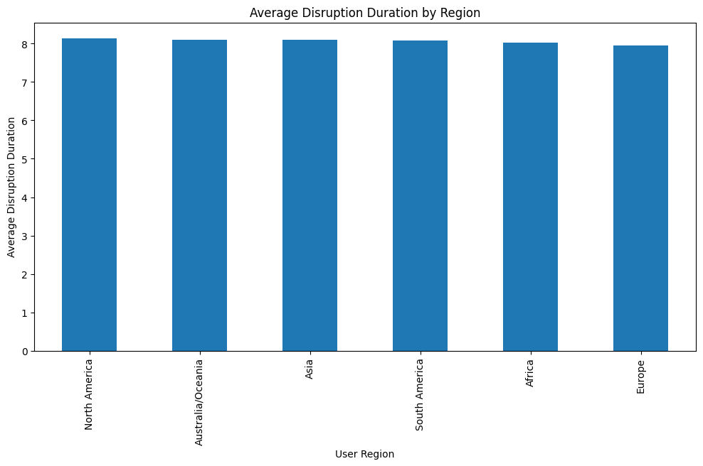

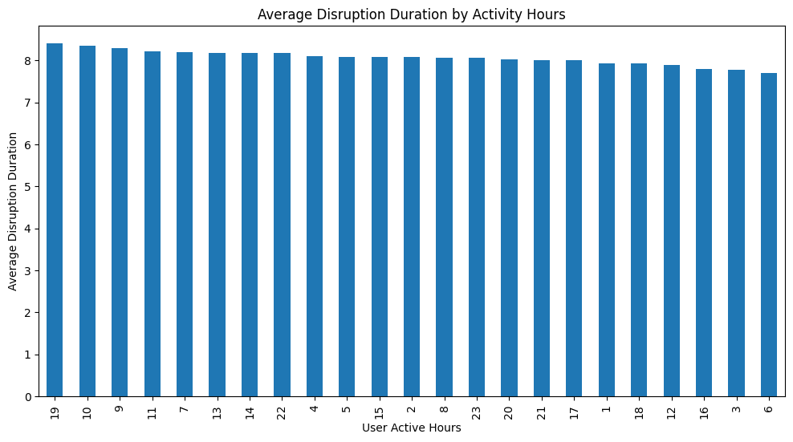

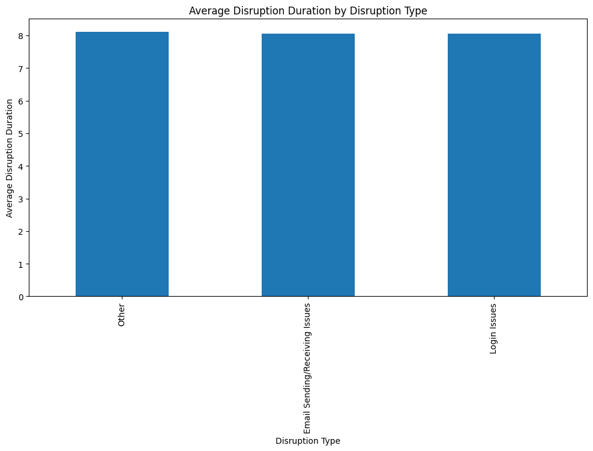

```python
# code block 8
# Import required libraries
import matplotlib.pyplot as plt

# Merge data
merged_data = pd.merge(gmail_service_disruption_df, gmail_user_df, on='User_ID')

# Analyze disruptions by region
region_disruptions = merged_data.groupby('User_Region')['Disruption_Duration'].mean().sort_values(ascending=False)
region_disruptions.plot(kind='bar', figsize=(12,6))
plt.title('Average Disruption Duration by Region')
plt.xlabel('User Region')
plt.ylabel('Average Disruption Duration')
plt.show()

# Analyze disruptions by activity hours
activity_hours_disruptions = merged_data.groupby('User_Active_Hours')['Disruption_Duration'].mean().sort_values(ascending=False)
activity_hours_disruptions.plot(kind='bar', figsize=(12,6))
plt.title('Average Disruption Duration by Activity Hours')
plt.xlabel('User Active Hours')
plt.ylabel('Average Disruption Duration')
plt.show()

# Analyze disruptions by disruption type
disruption_type_disruptions = merged_data.groupby('Disruption_Type')['Disruption_Duration'].mean().sort_values(ascending=False)
disruption_type_disruptions.plot(kind='bar', figsize=(12,6))
plt.title('Average Disruption Duration by Disruption Type')
plt.xlabel('Disruption Type')
plt.ylabel('Average Disruption Duration')
plt.show()
```

**Result Explanation**

The bar plots give a clear visualization of how disruption duration varies across different regions, user activity hours, and disruption types. For instance, if certain regions show longer average disruption durations, this could indicate the need for additional infrastructure or maintenance in those areas. Similarly, if disruptions are more frequent during specific user activity hours or for certain disruption types, these could be areas for Google's Email Services team to focus on for improving service reliability.

# Question 5

## **"Feature Engineering for Predictive Modeling"**

In preparation for creating a predictive model for 'RiskGroup' categorization, it's crucial to identify and engineer the right features. Analyze the 'GmailUserData' table and extract or create variables that may contribute to the risk profile of a user. This could involve generating new data attributes from existing ones, dealing with missing values, outliers, or applying transformations for improving model performance. Discuss your approach, rationale, and methods for feature engineering.

## Solution

1. **Merge DataFrames**: Merge 'GmailUserData', 'GmailUsageData', and 'GmailServiceDisruptionData' on 'User_ID'.
2. **Inspect Data**: Check the data types and non-null counts for each column.
3. **Data Cleaning**: Drop unnecessary columns like 'Disruption_Type'.
4. **Data Transformation**: Use one-hot encoding to transform categorical columns ('User_Region', 'Device_Type', and 'Browser_Type') into binary variables.
5. **Combine DataFrames**: Concatenate the one-hot encoded DataFrame with the original one.
6. **Final Clean Up**: Drop the original categorical columns and 'Disruption_Time' from the DataFrame.
7. **Final Inspection**: Check the data types and structure of the final DataFrame.

```python
# code block 9
# Merge the DataFrames on the 'User_ID' column
merged_df = pd.merge(gmail_user_df, gmail_usage_df, on='User_ID')
merged_df = pd.merge(merged_df, gmail_service_disruption_df, on='User_ID')

# The merging with 'ExternalTechTrendsData' will be more complex as it may not contain 'User_ID'.
# It needs a different kind of processing and may not be directly used in model building.

# Check the data types and non-null count for each column
print(merged_df.info())
```

```
<class 'pandas.core.frame.DataFrame'>
Int64Index: 2000 entries, 0 to 1999
Data columns (total 20 columns):
 #   Column                Non-Null Count  Dtype
---  ------                --------------  -----
 0   User_ID               2000 non-null   int64
 1   Risk_Group            2000 non-null   object
 2   User_Region           2000 non-null   object
 3   Account_Age           2000 non-null   int64
 4   User_Active_Hours     2000 non-null   int64
 5   Device_Type           2000 non-null   object
 6   Browser_Type          2000 non-null   object
 7   Login_Frequency       2000 non-null   float64
 8   Email_Sent            2000 non-null   int64
 9   Email_Received        2000 non-null   int64
 10  Chat_Usage            2000 non-null   float64
 11  Email_Storage         2000 non-null   int64
 12  Spam_Interaction      2000 non-null   int64
 13  Ad_Clicks             2000 non-null   int64
 14  Attachments_Sent      2000 non-null   int64
 15  Attachments_Received  2000 non-null   int64
 16  Disruption_Duration   2000 non-null   float64
 17  Disruption_Type       2000 non-null   object
 18  Disruption_Time       2000 non-null   datetime64[ns]
 19  Resolution_Time       2000 non-null   float64
dtypes: datetime64[ns](1), float64(4), int64(10), object(5)
memory usage: 328.1+ KB
None
```

```python
# code block 10
from sklearn.preprocessing import OneHotEncoder

# Drop the unnecessary columns
merged_df = merged_df.drop(["Disruption_Type"], axis=1)

# Initialize the OneHotEncoder
encoder = OneHotEncoder(sparse=False)

# Fit and transform the 'Risk_Group' and 'User_Region' columns
one_hot = encoder.fit_transform(merged_df[["User_Region", "Device_Type", "Browser_Type"]])

# Extract feature names
feature_names = encoder.get_feature_names_out(["User_Region", "Device_Type", "Browser_Type"])

# Create a DataFrame from the one-hot encoded variables
one_hot_df = pd.DataFrame(one_hot, columns=feature_names)

# Concatenate the original DataFrame with the one-hot encoded DataFrame
merged_df = pd.concat([merged_df, one_hot_df], axis=1)

# Drop the original encoded features
merged_df = merged_df.drop(["User_Region", "Device_Type", "Browser_Type", 'Disruption_Time'], axis=1)

# Check data types of final DataFrame
print(merged_df.info())
```

```
<class 'pandas.core.frame.DataFrame'>
Int64Index: 2000 entries, 0 to 1999
Data columns (total 29 columns):
 #   Column                         Non-Null Count  Dtype
---  ------                         --------------  -----
 0   User_ID                        2000 non-null   int64
 1   Risk_Group                     2000 non-null   object
 2   Account_Age                    2000 non-null   int64
 3   User_Active_Hours              2000 non-null   int64
 4   Login_Frequency                2000 non-null   float64
 5   Email_Sent                     2000 non-null   int64
 6   Email_Received                 2000 non-null   int64
 7   Chat_Usage                     2000 non-null   float64
 8   Email_Storage                  2000 non-null   int64
 9   Spam_Interaction               2000 non-null   int64
```

[output cut: 22 more lines]

The code merges the three tables that share 'User_ID', then checks the information of the resulting DataFrame. 'Disruption_Type' column gets dropped as it might not be significant for user risk prediction.

Next, the one-hot encoding process is initialized, and the transformation gets applied to 'User_Region', 'Device_Type', and 'Browser_Type'. A DataFrame is created from the encoded variables, and it gets concatenated with the original DataFrame. The original categorical features and 'Disruption_Time' are then dropped from the DataFrame.

Lastly, the final DataFrame's info is printed to review the final structure and data types before building the predictive model.

# Question 6

## **"Building a Predictive Model for Risk Group Categorization"**

Drawing on the insights and features you derived from preceding tasks, which variables would you flag as potential predictors for the 'RiskGroup' of Gmail users? How would you architect a predictive model that incorporates these features? Provide a methodological overview of how you would safeguard your model against overfitting. Based on the performance of your model, what potential amendments could be made to Gmail service optimization strategies to further enhance user satisfaction?

## Solution

**Predictive Variables:** To determine the potential predictive variables for the 'RiskGroup' of Gmail users, we would need to evaluate the data available. Here are some possible features:

1. Frequency of login
2. Duration of usage per session
3. Number of sent and received emails
4. Size of attachments sent or received
5. Number of reported spam emails
6. Frequency of password changes
7. Usage of two-factor authentication
8. Level of interaction with promotions or social tabs

**Model Architecture:** The provided code uses a Random Forest Classifier, a versatile algorithm that works well for both binary and multiclass classification problems. This algorithm creates a set of decision trees from a randomly selected subset of the training set, which then aggregates votes from different decision trees to decide the final class of the test object.

**Overfitting Safeguard:** Random Forest inherently protects against overfitting by averaging out the bias of individual trees, given a sufficiently large number of trees. However, you can further guard against overfitting by:

1. Tuning model parameters like the number of trees (n_estimators) or tree depth (max_depth).
2. Using cross-validation methods (like k-fold cross-validation) to generate unbiased estimates of model performance.
3. Regularizing the model (if applicable).
4. Monitoring the performance of the model not only on the training set, but also on the validation set.

```python
# code block 11
from sklearn.model_selection import train_test_split
from sklearn.ensemble import RandomForestClassifier
from sklearn.metrics import classification_report

# Select features
features = merged_df.drop('Risk_Group', axis=1)

# Select target
target = merged_df['Risk_Group']

# Split data into train and test sets
X_train, X_test, y_train, y_test = train_test_split(features, target, test_size=0.2, random_state=42)

# Initialize classifier
clf = RandomForestClassifier(n_estimators=100, random_state=42)

# Train model
clf.fit(X_train, y_train)

# Predict on test set
y_pred = clf.predict(X_test)

# Print classification report
print(classification_report(y_test, y_pred))

# Print feature importances
importances = clf.feature_importances_
feature_importances = pd.DataFrame({'Feature': features.columns, 'Importance': importances})
print(feature_importances.sort_values('Importance', ascending=False))
```

```
              precision    recall  f1-score   support

        High       0.87      0.84      0.85       108
         Low       0.80      0.88      0.84       131
      Medium       0.79      0.74      0.76       161

    accuracy                           0.81       400
   macro avg       0.82      0.82      0.82       400
weighted avg       0.81      0.81      0.81       400

                          Feature  Importance
7                   Email_Storage    0.217657
9                       Ad_Clicks    0.116896
3                 Login_Frequency    0.111335
5                  Email_Received    0.093934
```

[output cut: 24 more lines]

```python
# code block 12
from sklearn.metrics import f1_score

# Compute F1 Score
f1 = f1_score(y_test, y_pred, average='weighted') # 'weighted' takes into account label imbalance; it can be changed to 'micro', 'macro', 'samples' based on your need
print(f"The F1 Score is: {f1}")
```

```
The F1 Score is: 0.81164857267146
```

**Model Evaluation and Improvement:** The provided code calculates the F1 score as a measure of the model's performance. The F1 score is the harmonic mean of precision and recall and is a good metric when classes are imbalanced.

Based on the performance of the model, and particularly the feature importances output, potential improvement could be made to Gmail's service. For instance, if two-factor authentication usage and frequency of password changes are strong predictors of lower risk, Gmail could encourage these behaviors through user education or nudges. Similarly, if interaction with certain types of email correlates with higher risk, Gmail could improve its filtering or warning systems.

Please note that this is a general approach and should be adjusted as per the specific context and available data.